This notebook describes the analytics process for solving the optimization problem at Moodys.

# Step 1 : Selecting the relevant variables

The initial number of variables were around 400. We need to narrow them down to what is relevant from the perspective of data completeness. A list of variables have been arrived at. We need to start our analysis from this set of 64 variables.

```r
loan_df <- loan_combined %>% select(matches("Dealname","Poolname","loannumber",
 "AddedDate" ,                        "VintageDate" ,                      "LoanNumber" ,
 "mtABSStatus"  ,                     "mtABSStatusGroup"   ,               "mtAccountStatus"  ,
"mtAccrualType"   ,                  "mtAccruedInterest"  ,               "mtActualRemainingTerm" ,
"mtActualSeasoning" ,                "mtAmountFinanced"  ,                "mtAPR"    ,
"mtAssetClass" ,                     "mtAssetStatus"  ,                   "mtBalloonAmountCalc" ,
"mtBranchCode"  ,                    "mtCollateralType"  ,                "mtCollateralYear"   ,
"mtCustomerId" ,                     "mtDaysDelinquent"    ,              "mtDiscountRateApplied" ,
"mtFinancedDepositAllowance",        "mtFirstPaymentDueAMT"  ,            "mtInitialPayment"   ,
"mtInterestAmount"  ,                "mtInterestEarned"  ,                "mtLastpaymentAMT" ,
"mtLoanToValue"   ,                  "mtLTVCalc"   ,                      "mtMake"     ,
"mtMaturingPaymentAMT"   ,           "mtModel"       ,                    "mtMonthlyPayment"   ,
"mtNetLiquidationProceeds"  ,        "mtNetLossAmount"    ,               "mtNewUsedFlag"   ,
"mtOriginalBalance"   ,              "mtOriginalPrincipalBalance"    ,    "mtOriginalUnearned"  ,
"mtPayment"       ,                  "mtPostCode"    ,                    "mtPotLoss"   ,
"mtPrincipalAmount"    ,             "mtPurchasePrice"    ,               "mtRecoveries"  ,
"mtScheduledBalance"    ,            "mtScheduledPaymentNumber"  ,        "mtScheduledSeasoning" ,
 "mtTotalNumberOfPayment"  ,          "mtTotalPayment"   ,                 "mtTotalPaymentMTD"   ,
"mtVIN"  ,                           "mtPastDueAmount"  ,                 "mtCbalAdj"   ,
"mtScottishFlag" ,                   "mtNetInterest"  ,                   "mtNetRecoveries" ,
"mtNorthernIrishFlag"   ,            "mtPrincipalCollection"  ,           "mtPrincipalCollectionUndiscounted",
"mtPIFCollectionUndiscounted"  ))
```

[output not shown]

[output not shown]

[output cut: 990 more lines]

```r
loan_df$AddedDate <- loan_df$VintageDate <- loan_df$LoanNumber <- loan_df$mtAccrualType <- loan_df$mtAccruedInterest <- loan_df$mtAssetClass <-  <- NULL
```

[output not shown]

Some critical perspectives of variables which can be looked at are 1. mtABSStatus : It gives some categories of loans which are Normal , Delinquent etc : 7 classes available in this category 2. mtABSStatusGroup : 3 classes, somewhat related to the earlier one.

# First kind of analysis. : Pool with respect to average delinquency.

The performance of a pool can be assessed by connecting the delinquency with a pool. We will have to see if the expected delinquency is consumerate with the the risk associated with a pool.

Some variables that can be tested out would be

1. mtDaysDelinquent
2. mtPoolname

```r
pool_del1 <- loan_df %>% group_by(Poolname) %>% summarise(Avgdel = mean(mtDaysDelinquent,na.rm=TRUE))
```

```r
table(pool_del1$mtDaysDelinquent)
```

[output not shown]

# 11-Nov-2016

Let us now work on the new data set which we have got from the delinquency perspective

```r
pool_del1 <- Random_Data_20k_Records %>% group_by(Poolname) %>% summarise(Avgdel = mean(mtDaysDelinquent,na.rm=TRUE))
```

Let us look at some visualisation of the delinquency rates and study the behaviour

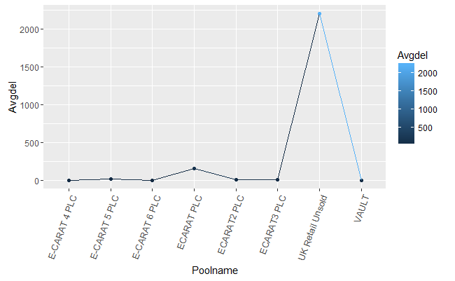

```r
library(ggplot2)
q1 <- ggplot(data=pool_del1,aes(Poolname,Avgdel,color=Avgdel,group=1)) + geom_point()+geom_line()
q1 + theme(axis.text.x=element_text(angle=70,hjust=1))+theme(axis.text.x = element_text(size = 10))
```

Let us also look at the mapping of pool to deal and vice versa